# MINI_project

```python
import pandas as pd
import numpy as np
import matplotlib.pyplot as plt
import seaborn as sns
```

```python
data = pd.read_csv("Zomoto.CSV")
```

```python
data.head()
```

|  | Unnamed: 0 | url | address | name | online_order | book_table | rate | votes | phone | location | rest_type | dish_liked | cuisines | approx_cost(for two people) | reviews_list | menu_item | listed_in(type) | listed_in(city) |
| --- | --- | --- | --- | --- | --- | --- | --- | --- | --- | --- | --- | --- | --- | --- | --- | --- | --- | --- |
| 0 | 14221 | https://www.zomato.com/bangalore/shree-ranga-v... | 366, Hosur Main Road, Attibele, Anekal Taluk, ... | Shree Ranga Vilas | No | No | 3.2/5 | 7 | 080 29765044 | Electronic City | Casual Dining | NaN | North Indian, South Indian, Chinese, Juices | 500 | [('Rated 3.0', 'RATED\n Typical South Indian ... | [] | Dine-out | Electronic City |
| 1 | 43422 | https://www.zomato.com/bangalore/sphyre-gatewa... | Gateway Hotel, 66, Residency Road, Bangalore | Sphyre - Gateway Hotel | No | No | 3.6 /5 | 45 | +91 9886643495\n+91 9898780004 | Residency Road | Lounge | NaN | Finger Food | 1,700 | [('Rated 1.0', 'RATED\n Expected a good night... | [] | Dine-out | MG Road |
| 2 | 16032 | https://www.zomato.com/bangalore/popular-baker... | 19, BDA Complex, HSR, Bangalore | Popular Bakery | No | No | 3.7/5 | 36 | +91 8105834605\r\n080 25722488 | HSR | Dessert Parlor, Bakery | NaN | Desserts, Bakery | 600 | [('Rated 5.0', "RATED\n This outlet is in HSR... | [] | Delivery | HSR |
| 3 | 51635 | https://www.zomato.com/bangalore/thai-chinese-... | 7, Anurhh Arcade, Hoodi Road, Kodigehalli Road... | Thai & Chinese Fast Food | No | No | 3.4 /5 | 7 | +91 9206260085\n+91 7619416923 | KR Puram | Quick Bites | NaN | Chinese, Thai | 400 | [('Rated 5.0', 'RATED\n Its Looking delicious... | [] | Dine-out | Whitefield |
| 4 | 23424 | https://www.zomato.com/bangalore/grill-on-whee... | Kothanuru Main Road, Puttenahalli Road, Natara... | Grill On Wheels | No | No | NEW | 0 | +91 9901979901 | JP Nagar | Quick Bites | NaN | North Indian, Chinese, BBQ, Arabian, Fast Food | 400 | [] | [] | Dine-out | JP Nagar |

```python
data["approx_cost(for two people)"].unique()
```

```
array(['500', '1,700', '600', '400', '350', '200', '2,600', '300', '700',
       '150', '1,400', '1,200', '800', '900', '250', '650', '2,000',
       '100', '2,800', '1,000', '450', '750', '950', '1,500', '850',
       '550', '1,300', '1,650', '1,100', '1,600', nan, '2,500', '2,300',
       '2,100', '2,400', '3,000', '70', '1,800', '4,100', '2,200',
       '3,400', '1,900', '1,450', '130', '40', '1,050', '1,350', '180',
       '1,250', '120', '3,500', '230', '469', '199', '6,000', '4,000',
       '80'], dtype=object)
```

## 2. Which are the top restaurant chains based on the distribution(frequency) in Bangaluru?

```python
data["name"].value_counts()
```

```
Cafe Coffee Day              18
Keventers                    17
Onesta                       17
McDonald's                   16
SGS Non Veg - Gundu Pulav    16
                             ..
Rufi's Kati Roll              1
MRS Paradise                  1
Cafe Mamma Mia                1
Hotel Food Lands              1
TBC- Sky Lounge               1
Name: name, Length: 4738, dtype: int64
```

## 3.How many restaurants do not accept online orders?

```python
data["online_order"].value_counts()
```

```
Yes    5943
No     4057
Name: online_order, dtype: int64
```

4057 restaurents do not accept online orders

## 4.What is the ratio b/w restaurants that provide and do not provide table booking?

```python
data["book_table"].value_counts(normalize=True)
```

```
No     0.8754
Yes    0.1246
Name: book_table, dtype: float64
```

the ratio is 0.87 to 0.12

## 5.Use a boxplot on the rating column. Use User Defined Function or Lambda function or Apply function to extract the data that comes before /. Kindly exclude /.

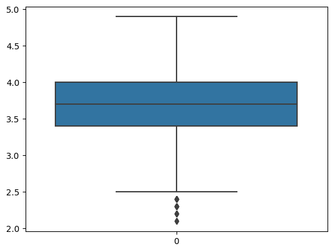

```python
def strip(data):
    l=[]
    string=''
    for i in data["rate"]:
        if type(i)== str:
            for j in i:
                if j.isdigit():
                    string=string+j
                if j=='.':
                    string=string+j
                if j=="/":
                    l.append(float(string))
                    string=''
                    break
        else:
            l.append(i)
    return l

sns.boxplot(strip(data))
```

## 6.Online and Offline orders restaurants percentage.

```python
data.head()
```

|  | Unnamed: 0 | url | address | name | online_order | book_table | rate | votes | phone | location | rest_type | dish_liked | cuisines | approx_cost(for two people) | reviews_list | menu_item | listed_in(type) | listed_in(city) |
| --- | --- | --- | --- | --- | --- | --- | --- | --- | --- | --- | --- | --- | --- | --- | --- | --- | --- | --- |
| 0 | 14221 | https://www.zomato.com/bangalore/shree-ranga-v... | 366, Hosur Main Road, Attibele, Anekal Taluk, ... | Shree Ranga Vilas | No | No | 3.2/5 | 7 | 080 29765044 | Electronic City | Casual Dining | NaN | North Indian, South Indian, Chinese, Juices | 500 | [('Rated 3.0', 'RATED\n Typical South Indian ... | [] | Dine-out | Electronic City |
| 1 | 43422 | https://www.zomato.com/bangalore/sphyre-gatewa... | Gateway Hotel, 66, Residency Road, Bangalore | Sphyre - Gateway Hotel | No | No | 3.6 /5 | 45 | +91 9886643495\n+91 9898780004 | Residency Road | Lounge | NaN | Finger Food | 1,700 | [('Rated 1.0', 'RATED\n Expected a good night... | [] | Dine-out | MG Road |
| 2 | 16032 | https://www.zomato.com/bangalore/popular-baker... | 19, BDA Complex, HSR, Bangalore | Popular Bakery | No | No | 3.7/5 | 36 | +91 8105834605\r\n080 25722488 | HSR | Dessert Parlor, Bakery | NaN | Desserts, Bakery | 600 | [('Rated 5.0', "RATED\n This outlet is in HSR... | [] | Delivery | HSR |
| 3 | 51635 | https://www.zomato.com/bangalore/thai-chinese-... | 7, Anurhh Arcade, Hoodi Road, Kodigehalli Road... | Thai & Chinese Fast Food | No | No | 3.4 /5 | 7 | +91 9206260085\n+91 7619416923 | KR Puram | Quick Bites | NaN | Chinese, Thai | 400 | [('Rated 5.0', 'RATED\n Its Looking delicious... | [] | Dine-out | Whitefield |
| 4 | 23424 | https://www.zomato.com/bangalore/grill-on-whee... | Kothanuru Main Road, Puttenahalli Road, Natara... | Grill On Wheels | No | No | NEW | 0 | +91 9901979901 | JP Nagar | Quick Bites | NaN | North Indian, Chinese, BBQ, Arabian, Fast Food | 400 | [] | [] | Dine-out | JP Nagar |

```python
data["online_order"].value_counts(normalize=True)
```

```
Yes    0.5943
No     0.4057
Name: online_order, dtype: float64
```

## 7.Plot the scatter plot using the Cost vs rating variable with respect to online order. Use apply the function Or other function to remove the “,”.

```python
def rating(x):
    if x=="-" or x=="NEW" or type(x)==float:
        return np.nan
    else:
        return float(x[:3])

data["rate"]=data["rate"].apply(rating)
```

```python
data["approx_cost(for two people)"]=data["approx_cost(for two people)"].replace(",","")
data["approx_cost(for two people)"]
```

[output not shown]

```python
l1=data[data["online_order"]=="Yes"]["approx_cost(for two people)"]
```

```python
l2=data[data["online_order"]=="Yes"]["rate"]
```

```python
df1=pd.DataFrame([l1,l2])
df1.T
```

|  | approx_cost(for two people) | rate |
| --- | --- | --- |
| 7 | 200.0 | 3.6 |
| 9 | 400.0 | 3.5 |
| 11 | 300.0 | 3.7 |
| 13 | 300.0 | 3.7 |
| 15 | 150.0 | 4.1 |
| ... | ... | ... |
| 9990 | 600.0 | 3.6 |
| 9992 | 250.0 | 3.8 |
| 9993 | 700.0 | 4.1 |
| 9995 | 1500.0 | 4.9 |
| 9999 | 300.0 | 3.7 |

5943 rows × 2 columns

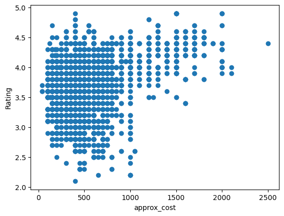

```python
plt.scatter(data=df1.T,x='approx_cost(for two people)',y='rate')
plt.xlabel("approx_cost")
plt.ylabel("Rating")
plt.show()
```

## 8.Find the distribution of the votes and Approx_cost using a user-defined function and for a loop.

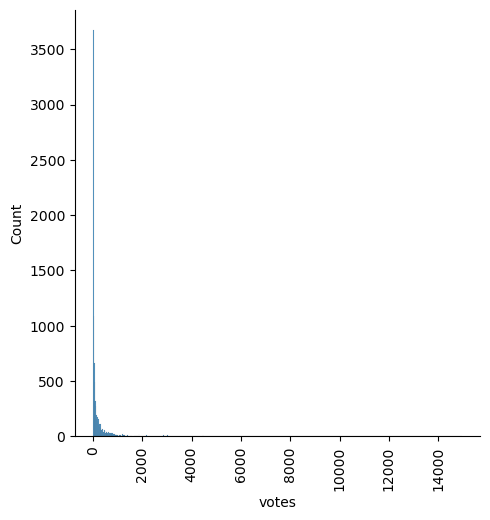

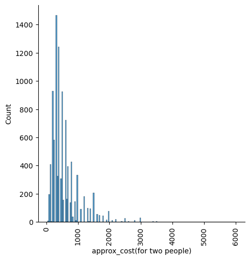

```python
def calculate_distribution(df,col):
    sns.displot(data=df,x=col)
    plt.xticks(rotation=90)
    plt.show()

for col in ("votes","approx_cost(for two people)"):
    calculate_distribution(data,col)
```

## 9.Which are the most common restaurant type in Banglore?

```python
data["rest_type"].value_counts()
```

```
Quick Bites                  3625
Casual Dining                2018
Cafe                          712
Delivery                      499
Dessert Parlor                443
                             ...
Food Court, Beverage Shop       1
Bar, Pub                        1
Casual Dining, Lounge           1
Quick Bites, Meat Shop          1
Bakery, Sweet Shop              1
Name: rest_type, Length: 82, dtype: int64
```

1.Quick Bites 2.Casual Dining 3.Cafe

```python
data.head()
```

[output not shown]

## 10.Is there any difference b/w the votes of restaurants accepting and not accepting online orders?

```python
data[data["online_order"]=="Yes"]["votes"].describe()
```

```
count    5943.000000
mean      302.117449
std       671.585547
min         0.000000
25%        19.000000
50%        75.000000
75%       273.500000
max      9085.000000
Name: votes, dtype: float64
```

```python
data[data["online_order"]=="No"]["votes"].describe()
```

```
count     4057.000000
mean       278.146907
std        983.073778
min          0.000000
25%          0.000000
50%         14.000000
75%         99.000000
max      14956.000000
Name: votes, dtype: float64
```

## 11. Which are the most common restaurant type in Banglore?

```python
data["rest_type"].value_counts()
```

```
Quick Bites                  3625
Casual Dining                2018
Cafe                          712
Delivery                      499
Dessert Parlor                443
                             ...
Food Court, Beverage Shop       1
Bar, Pub                        1
Casual Dining, Lounge           1
Quick Bites, Meat Shop          1
Bakery, Sweet Shop              1
Name: rest_type, Length: 82, dtype: int64
```

## 12. Find the Best budget Restaurants in any location.

```python
pd.pivot_table(data=data,index="listed_in(city)",values=["approx_cost(for two people)","name"],aggfunc=min)
```

| listed_in(city) | approx_cost(for two people) | name |
| --- | --- | --- |
| BTM | 70.0 | 100ÃÂÃÂÃÂÃÂ°C |
| Banashankari | 100.0 | 1947 |
| Bannerghatta Road | 100.0 | #refuel |
| Basavanagudi | 100.0 | 3 Spice |
| Bellandur | 100.0 | @ The Bbq |
| Brigade Road | 100.0 | 24 Carats - The Capitol |
| Brookefield | 100.0 | 9D Foods |
| Church Street | 40.0 | 24 Carats - The Capitol |
| Electronic City | 100.0 | #Vibes Restro |
| Frazer Town | 100.0 | 1Q1 |
| HSR | 100.0 | #L-81 Cafe |
| Indiranagar | 100.0 | 1131 Bar + Kitchen |
| JP Nagar | 100.0 | 1441 Pizzeria |
| Jayanagar | 80.0 | 1441 Pizzeria |
| Kalyan Nagar | 100.0 | 4 Seasons Restaurant |
| Kammanahalli | 100.0 | 2 Statez |
| Koramangala 4th Block | 40.0 | 12th Main - Grand Mercure |
| Koramangala 5th Block | 100.0 | 154 Breakfast Club |
| Koramangala 6th Block | 100.0 | 1522 - The Pub |
| Koramangala 7th Block | 100.0 | 12th Main - Grand Mercure |
| Lavelle Road | 100.0 | 21 Corner Haus Cafe |
| MG Road | 100.0 | 1Q1 |
| Malleshwaram | 100.0 | 1947 |
| Marathahalli | 100.0 | 99 Caffe |
| New BEL Road | 100.0 | 1522 - The Pub |
| Old Airport Road | 100.0 | 1131 Bar + Kitchen |
| Rajajinagar | 100.0 | 1992 Chats - Space |
| Residency Road | 100.0 | 1Q1 |
| Sarjapur Road | 100.0 | 38 Sugar Lane |
| Whitefield | 100.0 | 4700BC Popcorn |

## 13. Top quick bites restaurant chains in Banglore.

```python
data[data["rest_type"]=="Quick Bites"]["name"].value_counts()
```

```
McDonald's                         16
SGS Non Veg - Gundu Pulav          15
KFC                                15
Taco Bell                          13
Pizza Stop                         12
                                   ..
Jayanagara Donne Biryani            1
South Kitchen                       1
Sri Venkateshwara Vishnu Bhavan     1
Bengaluru's Biryanis Paradise       1
Food Square                         1
Name: name, Length: 1994, dtype: int64
```

## 14. Which are the most popular casual dining restaurant chains, Make use of any plot related to this question?

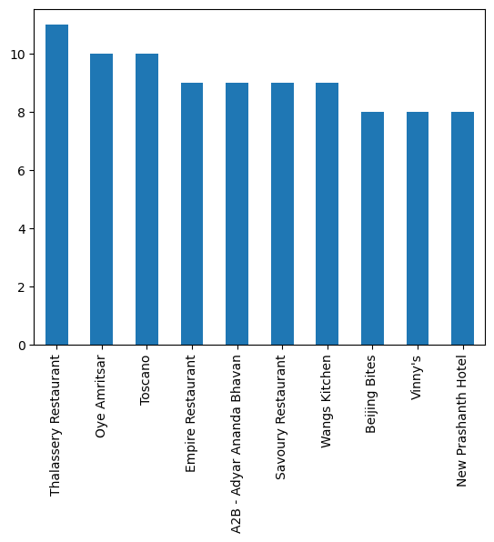

```python
data[data["rest_type"]=="Casual Dining"]["name"].value_counts().head(10).plot(kind="bar")
```

## 15. Which are the most popular cuisines of Bangalore using a related plot?

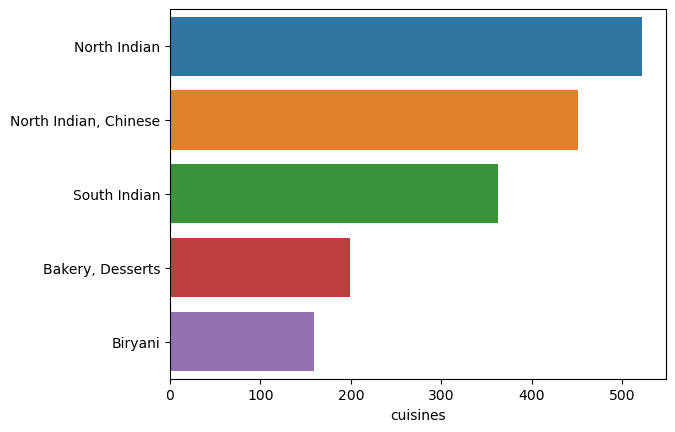

```python
cuisines = data['cuisines'].value_counts().head()
sns.barplot(x=cuisines,y=cuisines.index)
plt.show()
```